This tutorial is automatically generated from the file test/python/tutorials//TestPythonLatticeBasedAngiogenesisTutorial.py.

```python
# Jupyter notebook specific imports
import matplotlib as mpl
from IPython import display
%matplotlib inline
```

# A Lattice Based Angiogenesis Tutorial

This tutorial introduces a lattice based angiogenesis problem based on a simplified version of the vascular tumour application described in [Owen et al. 2011](http://www.ncbi.nlm.nih.gov/pubmed/21363914).

It is a 2D simulation using cellular automaton for cells, a regular grid for vessel movement and the same grid for the solution of partial differential equations for oxygen and VEGF transport using the finite difference method.

## The Test

```python
import chaste # Core Chaste functionality
import chaste.cell_based # Chaste Cell Populations
chaste.init() # Initialize MPI and PETSc
import microvessel_chaste # Core Microvessel Chaste functionality
import microvessel_chaste.geometry # Geometry tools
import microvessel_chaste.mesh # Meshing
import microvessel_chaste.population.vessel # Vessel tools
import microvessel_chaste.pde # PDE and solvers
import microvessel_chaste.simulation # Flow and angiogenesis solvers
import microvessel_chaste.visualization # Visualization
from microvessel_chaste.utility import * # Dimensional analysis: bring in all units for convenience
# Set up the test
chaste.cell_based.SetupNotebookTest()
```

Set up output file management and seed the random number generator.

```python
file_handler = chaste.core.OutputFileHandler("Python/TestLatticeBasedAngiogenesisTutorial")
chaste.core.RandomNumberGenerator.Instance().Reseed(12345)
```

This component uses explicit dimensions for all quantities, but interfaces with solvers which take non-dimensional inputs. The `BaseUnits` singleton takes time, length and mass reference scales to allow non-dimensionalisation when sending quantities to external solvers and re-dimensionalisation of results. For our purposes microns for length and hours for time are suitable base units.

```python
reference_length = 1.e-6 * metre()
reference_time = 3600.0 * second()
BaseUnits.Instance().SetReferenceLengthScale(reference_length)
BaseUnits.Instance().SetReferenceTimeScale(reference_time)
```

Set up the lattice (grid), we will use the same dimensions as [Owen et al. 2011](http://www.ncbi.nlm.nih.gov/pubmed/21363914). Note that we are using hard-coded parameters from that paper. You can see the values by printing. When we get the value of the parameter by doing `Owen11Parameters.mpLatticeSpacing.GetValue("User")` a record is kept that this parameter has been used in the simulation. A record of all parameters used in a simulation can be dumped to file on completion, as will be shown below.

```python
grid = microvessel_chaste.mesh.RegularGrid2()
grid_spacing = Owen11Parameters.mpLatticeSpacing.GetValue("User")
grid.SetSpacing(grid_spacing)
grid.SetExtents([51, 51, 1])
```

We can write and visualize the grid.

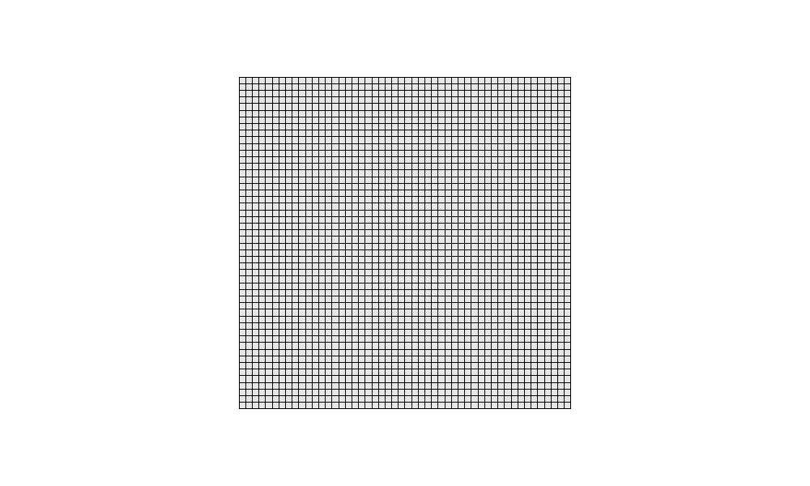

```python
grid.Write(file_handler)
scene = microvessel_chaste.visualization.MicrovesselVtkScene2()
scene.SetRegularGrid(grid)
scene.GetRegularGridActorGenerator().SetVolumeOpacity(0.1)
nb_manager = microvessel_chaste.visualization.JupyterNotebookManager()
nb_manager.vtk_show(scene, height=600, width = 1000)
```

Next, set up the vessel network, this will initially consist of two, large counter-flowing vessels. Also set the inlet and outlet pressures and flags.

```python
node1 = microvessel_chaste.population.vessel.VesselNode2.Create(0.0, 400.0, 0.0, reference_length)
node2 = microvessel_chaste.population.vessel.VesselNode2.Create(2000.0, 400.0, 0.0, reference_length)
node1.GetFlowProperties().SetIsInputNode(True)
node1.GetFlowProperties().SetPressure(Owen11Parameters.mpInletPressure.GetValue("User"))
node2.GetFlowProperties().SetIsOutputNode(True);
node2.GetFlowProperties().SetPressure(Owen11Parameters.mpOutletPressure.GetValue("User"))
node3 = microvessel_chaste.population.vessel.VesselNode2.Create(2000.0, 1600.0, 0.0, reference_length)
node4 = microvessel_chaste.population.vessel.VesselNode2.Create(0.0, 1600.0, 0.0, reference_length)
node3.GetFlowProperties().SetIsInputNode(True)
node3.GetFlowProperties().SetPressure(Owen11Parameters.mpInletPressure.GetValue("User"))
node4.GetFlowProperties().SetIsOutputNode(True)
node4.GetFlowProperties().SetPressure(Owen11Parameters.mpOutletPressure.GetValue("User"))
vessel1 = microvessel_chaste.population.vessel.Vessel2.Create(node1, node2)
vessel2 = microvessel_chaste.population.vessel.Vessel2.Create(node3, node4)
network = microvessel_chaste.population.vessel.VesselNetwork2.Create()
network.AddVessel(vessel1)
network.AddVessel(vessel2)
```

Again, we can visualize and write the network

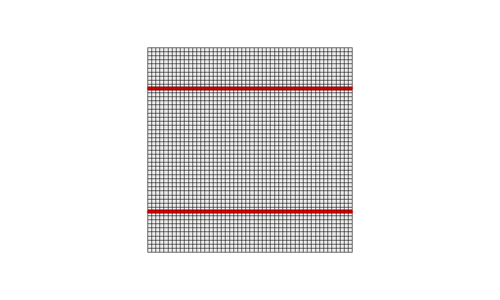

```python
scene.SetVesselNetwork(network)
scene.GetVesselNetworkActorGenerator().SetEdgeSize(20.0)
network.Write(file_handler.GetOutputDirectoryFullPath() + "initial_network.vtp")
nb_manager.vtk_show(scene, height=600, width = 1000)
```

Next, set up the cell populations. We will setup up a population similar to that used in the Owen et al., 2011 paper. That is, a grid filled with normal cells and a tumour spheroid in the middle. We can use a generator for this purpose. The generator simply sets up the population using conventional Cell Based Chaste methods.

```python
cell_population_genenerator = microvessel_chaste.population.cell.Owen11CellPopulationGenerator2()
cell_population_genenerator.SetRegularGrid(grid)
cell_population_genenerator.SetVesselNetwork(network)
tumour_radius = 300.0 * 1.e-6 * metre()
cell_population_genenerator.SetTumourRadius(tumour_radius)
cell_population = cell_population_genenerator.Update()
```

Again, we visualize. First turn off the grid edges so it is easier to see the cells.

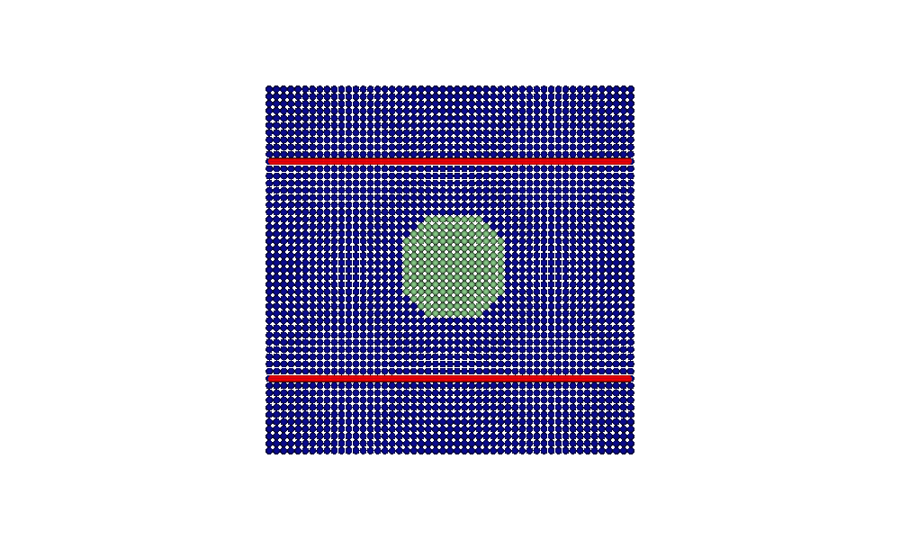

```python
scene.GetRegularGridActorGenerator().SetShowEdges(False)
scene.GetRegularGridActorGenerator().SetVolumeOpacity(0.0)
scene.SetCellPopulation(cell_population)
scene.GetCellPopulationActorGenerator().GetDiscreteColorTransferFunction().AddRGBPoint(1.0, 0.0, 0.0, 0.6)
scene.GetCellPopulationActorGenerator().SetPointSize(20)
scene.GetCellPopulationActorGenerator().SetColorByCellMutationState(True)
nb_manager.vtk_show(scene, height=600, width = 1000)
```

Next set up the PDEs for oxygen and VEGF. Cells will act as discrete oxygen sinks and discrete vegf sources.

```python
oxygen_pde = microvessel_chaste.pde.LinearSteadyStateDiffusionReactionPde2_2()
oxygen_pde.SetIsotropicDiffusionConstant(Owen11Parameters.mpOxygenDiffusivity.GetValue("User"))
cell_oxygen_sink = microvessel_chaste.pde.CellBasedDiscreteSource2()
cell_oxygen_sink.SetLinearInUConsumptionRatePerCell(Owen11Parameters.mpCellOxygenConsumptionRate.GetValue("User"))
oxygen_pde.AddDiscreteSource(cell_oxygen_sink)
```

Vessels release oxygen depending on their haematocrit levels

```python
vessel_oxygen_source = microvessel_chaste.pde.VesselBasedDiscreteSource2()
#oxygen_solubility_at_stp = Secomb04Parameters.mpOxygenVolumetricSolubility.GetValue("User") * GenericParameters.mpGasConcentrationAtStp.GetValue("User")
#vessel_oxygen_concentration = oxygen_solubility_at_stp * Owen11Parameters.mpReferencePartialPressure.GetValue("User")
vessel_oxygen_concentration = 0.02768 * mole_per_metre_cubed()
vessel_oxygen_source.SetReferenceConcentration(vessel_oxygen_concentration)
vessel_oxygen_source.SetVesselPermeability(Owen11Parameters.mpVesselOxygenPermeability.GetValue("User"))
vessel_oxygen_source.SetReferenceHaematocrit(Owen11Parameters.mpInflowHaematocrit.GetValue("User"))
oxygen_pde.AddDiscreteSource(vessel_oxygen_source);
```

Set up a finite difference solver and pass it the pde and grid.

```python
oxygen_solver = microvessel_chaste.pde.FiniteDifferenceSolver2()
oxygen_solver.SetPde(oxygen_pde)
oxygen_solver.SetLabel("oxygen")
oxygen_solver.SetGrid(grid)
```

The rate of VEGF release depends on the cell type and intracellular VEGF levels, so we need a more detailed type of discrete source.

```python
vegf_pde = microvessel_chaste.pde.LinearSteadyStateDiffusionReactionPde2_2()
vegf_pde.SetIsotropicDiffusionConstant(Owen11Parameters.mpVegfDiffusivity.GetValue("User"))
vegf_pde.SetContinuumLinearInUTerm(-1.0 * Owen11Parameters.mpVegfDecayRate.GetValue("User"))
```

Set up a map for different release rates depending on cell type. Also include a threshold intracellular VEGF below which there is no release.

```python
normal_and_quiescent_cell_source = microvessel_chaste.pde.CellStateDependentDiscreteSource2()
normal_and_quiescent_cell_rates = microvessel_chaste.pde.MapUnsigned_ConcentrationFlowRate()
normal_and_quiescent_cell_rate_thresholds = microvessel_chaste.pde.MapUnsigned_Concentration()
quiescent_cancer_state = microvessel_chaste.population.cell.QuiescentCancerCellMutationState()
normal_cell_state = chaste.cell_based.WildTypeCellMutationState()
normal_and_quiescent_cell_rates[normal_cell_state.GetColour()] = Owen11Parameters.mpCellVegfSecretionRate.GetValue("User")
normal_and_quiescent_cell_rate_thresholds[normal_cell_state.GetColour()] = 0.27*mole_per_metre_cubed()
normal_and_quiescent_cell_rates[quiescent_cancer_state.GetColour()] = Owen11Parameters.mpCellVegfSecretionRate.GetValue("User")
normal_and_quiescent_cell_rate_thresholds[quiescent_cancer_state.GetColour()] = 0.0*mole_per_metre_cubed()
normal_and_quiescent_cell_source.SetStateRateMap(normal_and_quiescent_cell_rates)
normal_and_quiescent_cell_source.SetLabelName("VEGF")
normal_and_quiescent_cell_source.SetStateRateThresholdMap(normal_and_quiescent_cell_rate_thresholds)
vegf_pde.AddDiscreteSource(normal_and_quiescent_cell_source)
```

Add a vessel related VEGF sink

```python
vessel_vegf_sink = microvessel_chaste.pde.VesselBasedDiscreteSource2()
vessel_vegf_sink.SetReferenceConcentration(0.0*mole_per_metre_cubed())
vessel_vegf_sink.SetVesselPermeability(Owen11Parameters.mpVesselVegfPermeability.GetValue("User"))
vegf_pde.AddDiscreteSource(vessel_vegf_sink)
```

Set up a finite difference solver as before.

```python
vegf_solver = microvessel_chaste.pde.FiniteDifferenceSolver2()
vegf_solver.SetPde(vegf_pde)
vegf_solver.SetLabel("VEGF_Extracellular")
vegf_solver.SetGrid(grid)
```

Next set up the flow problem. Assign a blood plasma viscosity to the vessels. The actual viscosity will depend on haematocrit and diameter. This solver manages growth and shrinkage of vessels in response to flow related stimuli.

```python
large_vessel_radius = 25.0e-6 * metre()
network.SetSegmentRadii(large_vessel_radius)
viscosity = Owen11Parameters.mpPlasmaViscosity.GetValue("User")
network.SetSegmentViscosity(viscosity);
```

Set up the pre- and post flow calculators.

```python
impedance_calculator = microvessel_chaste.simulation.VesselImpedanceCalculator2()
haematocrit_calculator = microvessel_chaste.simulation.ConstantHaematocritSolver2()
haematocrit_calculator.SetHaematocrit(Owen11Parameters.mpInflowHaematocrit.GetValue("User"))
wss_calculator = microvessel_chaste.simulation.WallShearStressCalculator2()
mech_stimulus_calculator = microvessel_chaste.simulation.MechanicalStimulusCalculator2()
metabolic_stim_calculator = microvessel_chaste.simulation.MetabolicStimulusCalculator2()
shrinking_stimulus_calculator = microvessel_chaste.simulation.ShrinkingStimulusCalculator2()
viscosity_calculator = microvessel_chaste.simulation.ViscosityCalculator2()
```

Set up and configure the structural adaptation solver.

```python
structural_adaptation_solver = microvessel_chaste.simulation.StructuralAdaptationSolver2()
structural_adaptation_solver.SetTolerance(0.0001)
structural_adaptation_solver.SetMaxIterations(100)
structural_adaptation_solver.SetTimeIncrement(Owen11Parameters.mpVesselRadiusUpdateTimestep.GetValue("User"));
structural_adaptation_solver.AddPreFlowSolveCalculator(impedance_calculator)
structural_adaptation_solver.AddPostFlowSolveCalculator(haematocrit_calculator)
structural_adaptation_solver.AddPostFlowSolveCalculator(wss_calculator)
structural_adaptation_solver.AddPostFlowSolveCalculator(metabolic_stim_calculator)
structural_adaptation_solver.AddPostFlowSolveCalculator(mech_stimulus_calculator)
structural_adaptation_solver.AddPostFlowSolveCalculator(viscosity_calculator)
```

Set up a regression solver.

```python
regression_solver = microvessel_chaste.simulation.WallShearStressBasedRegressionSolver2()
```

Set up an angiogenesis solver and add sprouting and migration rules.

```python
angiogenesis_solver = microvessel_chaste.simulation.AngiogenesisSolver2()
sprouting_rule = microvessel_chaste.simulation.Owen2011SproutingRule2()
migration_rule = microvessel_chaste.simulation.Owen2011MigrationRule2()
angiogenesis_solver.SetMigrationRule(migration_rule)
angiogenesis_solver.SetSproutingRule(sprouting_rule)
sprouting_rule.SetDiscreteContinuumSolver(vegf_solver)
migration_rule.SetDiscreteContinuumSolver(vegf_solver)
angiogenesis_solver.SetVesselGrid(grid)
angiogenesis_solver.SetVesselNetwork(network)
```

The microvessel solver will manage all aspects of the vessel solve.

```python
microvessel_solver = microvessel_chaste.simulation.MicrovesselSolver2()
microvessel_solver.SetVesselNetwork(network)
microvessel_solver.SetOutputFrequency(5)
microvessel_solver.AddDiscreteContinuumSolver(oxygen_solver)
microvessel_solver.AddDiscreteContinuumSolver(vegf_solver)
microvessel_solver.SetStructuralAdaptationSolver(structural_adaptation_solver)
microvessel_solver.SetRegressionSolver(regression_solver)
microvessel_solver.SetAngiogenesisSolver(angiogenesis_solver)
```

Set up plotting

```python
scene.GetCellPopulationActorGenerator().SetColorByCellData(True)
scene.GetCellPopulationActorGenerator().SetDataLabel("oxygen")
scene_modifier = microvessel_chaste.visualization.JupyterMicrovesselSceneModifier2(nb_manager)
scene_modifier.SetVtkScene(scene)
scene_modifier.SetUpdateFrequency(2)
microvessel_solver.AddMicrovesselModifier(scene_modifier)
```

The microvessel solution modifier will link the vessel and cell solvers. We need to explicitly tell it which extracellular fields to update based on PDE solutions.

```python
microvessel_modifier = microvessel_chaste.simulation.MicrovesselSimulationModifier2()
microvessel_modifier.SetMicrovesselSolver(microvessel_solver)
update_labels = microvessel_chaste.simulation.VecString()
update_labels.append("oxygen")
update_labels.append("VEGF_Extracellular")
microvessel_modifier.SetCellDataUpdateLabels(update_labels)
```

The full simulation is run as a typical Cell Based Chaste simulation

```python
simulator = chaste.cell_based.OnLatticeSimulation2(cell_population)
simulator.AddSimulationModifier(microvessel_modifier)
```

Add a killer to remove apoptotic cells

```python
apoptotic_cell_killer = chaste.cell_based.ApoptoticCellKiller2(cell_population)
simulator.AddCellKiller(apoptotic_cell_killer)
```

Add another modifier for updating cell cycle quantities.

```python
owen11_tracking_modifier = microvessel_chaste.simulation.Owen2011TrackingModifier2()
simulator.AddSimulationModifier(owen11_tracking_modifier)
```

Set up the remainder of the simulation

```python
simulator.SetOutputDirectory("Python/TestLatticeBasedAngiogenesisLiteratePaper")
simulator.SetSamplingTimestepMultiple(5)
simulator.SetDt(0.5)
```

This end time corresponds to roughly 10 minutes run-time on a desktop PC. Increase it or decrease as preferred. The end time used in Owen et al. 2011 is 4800 hours.

```python
simulator.SetEndTime(20.0)
```

[figure not shown]

```python
simulator.Solve()
```

Dump the parameters to file for inspection.

```python
ParameterCollection.Instance().DumpToFile(file_handler.GetOutputDirectoryFullPath()+"parameter_collection.xml")
nb_manager.add_parameter_table(file_handler)
# Tear down the test
chaste.cell_based.TearDownNotebookTest()
```

| name | value | symbol | added_by | description |
| --- | --- | --- | --- | --- |
| Generic_GasConcentrationAtStp | 44.6429 m^-3 mol | $$C_{stp}$$ | Owen2011OxygenBasedCellCycleOdeSystem | Gas concentration at STP |
| Owen11_BasalMetabolicStimulus | 1.7 Hz | $$k^0_m$$ | MetabolicStimulusCalculator | Basal metabolic stimulus |
| Owen11_CellMotilityCancer | 8.33333e-15 m^2 s^-1 | $$D_{cancer}$$ | Owen11CaUpdateRule | Maximum cell motility cancer |
| Owen11_CellMotilityEndothelial | 1.66667e-14 m^2 s^-1 | $$D_{endo}$$ | Owen2011MigrationRule | Maximum cell motility endothelial |
| Owen11_CellOxygenConsumptionRate | 0.216667 Hz | $$k_c^{cell}$$ | User | Cell oxygen consumption rate |
| Owen11_CellVegfProductionRate | 3.33333e-05 Hz | $$k_8$$ | Owen2011OxygenBasedCellCycleOdeSystem | Basal VEGF production rate in cell |
| Owen11_CellVegfSecretionRate | 1.66667e-13 m^-3 s^-1 mol | $$k_v^{cell}$$ | User | Cell vegf secretion rate |
| Owen11_ChemotacticSensitivity | 0.333333 m^5 s^-1 mol^-1 | $$\Chi$$ | Owen2011MigrationRule | Chemotactic sensitivity |
| Owen11_CriticalWallShearStress | 0.8 Pa | $$\tau_{wall}$$ | WallShearStressBasedRegressionSolver | Critical wall shear stress for vessel pruning |
| Owen11_InflowHaematocrit | 0.45 dimensionless | $$H_{in}$$ | User | Inflow haematocrit |
| Owen11_InletPressure | 3333.05 Pa | $$P_{in}$$ | User | Vessel network inlet pressure$ |
| Owen11_LatticeSpacing | 4e-05 m | $$\Delta x$$ | User | Lattice spacing |
| Owen11_MaxCellVegfProductionRate | 0.000166667 Hz | $$k_8_dash$$ | Owen2011OxygenBasedCellCycleOdeSystem | Max VEGF production rate in cell |
| Owen11_MaxTimeWithLowWallShearStress | 240000 s | $$T_{prune}$$ | WallShearStressBasedRegressionSolver | Maximum vessel survivial time with low wall shear stress |
| Owen11_MaximumRadius | 5e-05 m | $$R_{MAX}$$ | RadiusCalculator | Maximum possible radius |
| Owen11_MaximumSproutingRate | 4.16667e-06 Hz | $$P^{max}_{sprout}$$ | Owen2011SproutingRule | Maximum rate of sprouting |
| Owen11_MinCellCycleCancer | 96000 s | $$T_{min}_{cancer}$$ | Owen2011OxygenBasedCellCycleOdeSystem | Minimum cell cycle period cancer |
| Owen11_MinCellCycleNormal | 180000 s | $$T_{min}_{normal}$$ | Owen2011OxygenBasedCellCycleOdeSystem | Minimum cell cycle period normal |
| Owen11_MinimumRadius | 1e-06 m | $$R_{MIN}$$ | RadiusCalculator | Minimum possible radius |
| Owen11_OutletPressure | 1999.83 Pa | $$P_{out}$$ | User | Vessel network outlet pressure |
| Owen11_OxygenAtHalfMaxCycleRateCancer | 186.651 Pa | $$C_{\phi}_{cancer}$$ | Owen2011OxygenBasedCellCycleOdeSystem | Oxygen partial pressure at half max cell cycle rate cancer |
| Owen11_OxygenAtHalfMaxCycleRateNormal | 399.966 Pa | $$C_{\phi}_{normal}$$ | Owen2011OxygenBasedCellCycleOdeSystem | Oxygen partial pressure at half max cell cycle rate normal |
| Owen11_OxygenAtQuiescence | 1186.57 Pa | $$C^{enter}_{quiesc}$$ | Owen2011OxygenBasedCellCycleModel | Oxygen partial pressure at quiescence |
| Owen11_OxygenDiffusivity | 2.41667e-09 m^2 s^-1 | $$D_{c}$$ | User | Oxygen diffusivity |
| Owen11_OxygenLeaveQuiescence | 1306.56 Pa | $$C^{leave}_{quiesc}$$ | Owen2011OxygenBasedCellCycleModel | Oxygen partial pressure to leave quiescence |
| Owen11_OxygenTensionForHalfMaxP53Degradation | 591.95 Pa | $$C_{p53}$$ | Owen2011OxygenBasedCellCycleOdeSystem | Tissue oxygen tension for half-max p53 degradation |
| Owen11_OxygenTensionForHalfMaxVegfDegradation | 591.95 Pa | $$C_{VEGF}$$ | Owen2011OxygenBasedCellCycleOdeSystem | Tissue oxygen tension for half-max vegf degradation |
| Owen11_P53EffectOnVegfProduction | -3.33333e-05 Hz | $$k_8_dash_dash$$ | Owen2011OxygenBasedCellCycleOdeSystem | Effect of P53 on VEGF production |
| Owen11_P53MaxDegradationRate | 0.000166667 Hz | $$k_dash_7$$ | Owen2011OxygenBasedCellCycleOdeSystem | Max p53 degradation rate |
| Owen11_P53ProductionRateConstant | 3.33333e-05 Hz | $$k_7$$ | Owen2011OxygenBasedCellCycleOdeSystem | Intracellular p53 production rate constant |
| Owen11_PlasmaViscosity | 0.0012 m^-1 kg s^-1 | $$\mu_{plasma}$$ | ViscosityCalculator | Blood plasma viscosity |
| Owen11_ReferenceFlowRateForMetabolicStimulus | 6.66667e-13 m^3 s^-1 | $$Q_{ref}$$ | MetabolicStimulusCalculator | Reference flow rate for metabolic stimulus |
| Owen11_SensitivityToIntravascularPressure | 0.5 Hz | $$k_p$$ | MechanicalStimulusCalculator | Shrinking to intravascaulr pressure |
| Owen11_ShrinkingTendency | 1.7 Hz | $$k_s$$ | ShrinkingStimulusCalculator | Shrinking tendency |
| Owen11_TimeDeathQuiescence | 240000 s | $$T_{death}$$ | Owen2011OxygenBasedCellCycleModel | Time for death due to sustained quiescence |
| Owen11_VegfConventrationAtHalfMaxProbSprouting | 5e-10 m^-3 mol | $$V_{sprout}$$ | Owen2011SproutingRule | VEGF concentration at half maximal vessel sprouting probability |
| Owen11_VegfDecayRate | 0.000166667 Hz | $$\delta_{v}$$ | User | Vegf decay rate |
| Owen11_VegfDiffusivity | 1.66667e-11 m^2 s^-1 | $$D_{v}$$ | User | Vegf diffusivity |
| Owen11_VegfEffectOnVegfProduction | 0.04 dimensionless | $$j_5$$ | Owen2011OxygenBasedCellCycleOdeSystem | Effect of VEGF on VEGF production |
| Owen11_VesselOxygenPermeability | 0.001 m s^-1 | $$\psi_{c}$$ | User | Vessel permeability to oxygen |
| Owen11_VesselRadiusUpdateTimestep | 0.1 s | $$\epsilon_t$$ | User | Vessel radius update timestep |
| Owen11_VesselVegfPermeability | 1.66667e-09 m s^-1 | $$\psi_{v}$$ | User | Vessel permeability to vegf |
| Secomb04_OxygenVolumetricSolubility | 2.3252e-07 m kg^-1 s^2 | $$\alpha_{eff}$$ | Owen2011OxygenBasedCellCycleOdeSystem | Oxygen solubility |